# Assignment2-Rishi-Android

Ayush Rishi

2024-03-22

# **Topic Description**

Android is my topic which is an operating system used in almost all the smart devices across the world. Here we have following details:

- Link - https://github.com/topics/android
- Repositories - We have total 115,766 public repositories.
- Followers - We have total 146K followers.
- Released Date - September 23, 2008
- Filter Options - There are many filter options available such as Language, sort List of Required.

## Libraries for exceution

```r
library(httr)
library(jsonlite)
library(magrittr)
library(gh)
library(purrr)
library(dplyr)
library(knitr)
library(kableExtra)
library(lubridate)
```

```r
library(ggplot2)
library(ggthemes)
library(tidyr)
```

## **Fetching 100 repos from Android**

```r
gitKey = "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"
Sys.setenv(GITHUB_PAT = gitKey)
response = gh("/search/repositories?q=topic:android",.limit = 100)
```

## **Table with columns name as full_name, created_at, size, language, topics in items sorted by size in descending order**

```r
df <- map_df(
  response$items,
  ~ tibble(
    full_name = .x$full_name,
    created_at = .x$created_at,
    size = .x$size,
    language = .x$language,
    topics = paste(.x$topics, collapse = ", ")
  )
) %>%
arrange(desc(size))

df <- slice(df, 1:10)
num_columns <- ncol(df)
column_width <- "4cm"

column_widths <- rep(column_width, num_columns)
kable(df, format = "html",
      align = "c", caption = "Top 10 Repository sorted by size", escape = FALSE, row.names = FALSE) %>%
  kable_styling(full_width = TRUE, bootstrap_options = c("striped", "hover", "condensed", "responsive"), position = "center") %>%
  column_spec(column = 1:num_columns, width = column_widths)
```

Top 10 Repository sorted by size

| full_name | created_at | size | language | topics |
| --- | --- | --- | --- | --- |
| dcloudio/uni-app | 2018-07-12T08:52:39Z | 3255802 | JavaScript | android, cross-platform, crossplatform, hbuilderx, ios, javascript, miniprogram, uni, uni-app, uniapp, vue, vue3 |
| expo/expo | 2016-08-15T17:14:25Z | 2986954 | TypeScript | android, app-framework, expo, framework, frontend, ios, javascript, mobile, native, native-apps, react, react-native, typescript, universal, web, web-framework |
| google/material-design-icons | 2014-10-08T18:01:28Z | 2273418 | NA | android, icons, ios, material, material-design, sprites, web |
| Anuken/Mindustry | 2017-04-30T01:24:29Z | 1834935 | Java | android, desktop, game, java, mindustry, mobile-game, multiplatform, rts, sandbox-game, tower-defense |
| xbmc/xbmc | 2011-01-03T21:18:51Z | 1608853 | C++ | android, c-plus-plus, entertainment-hub, hacktoberfest, home-theater, ios, kodi, linux, macos, media-center, media-player, multimedia, python, windows-desktop, windows-uwp, xbmc, xml |
| libgdx/libgdx | 2012-08-10T19:34:38Z | 1102870 | Java | 2d, 3d, android, cross-platform, framework, game, game-development, game-engine, gamedev, html5, ios, java, libgdx, linux, macosx, windows |
| cocos2d/cocos2d-x | 2010-11-18T23:17:00Z | 988721 | C++ | android, c-plus-plus, cocos2d, cocos2d-x, game-development, game-engine, gamedev, ios, linx, lua, metal, windows |
| facebook/react-native | 2015-01-09T18:10:16Z | 875818 | C++ | android, app-framework, cross-platform, ios, mobile, mobile-development, react, react-native |
| wasabeef/awesome-android-ui | 2014-12-24T01:45:03Z | 871781 | NA | android, awesome, ui |
| google/filament | 2018-08-03T17:26:00Z | 689438 | C++ | 3d-graphics, android, gltf, gltf-viewer, graphics, metal, opengl, opengl-es, pbr, real-time, vulkan, wasm, webgl |

## **Fetching 100 Owners details through login**

```r
repos <- response$items
Owner_Summary <- function(repos) {
  owner_login <- repos$owner$login
  owner_info <- gh("/users/{login}", login = owner_login)
  data.frame(
    login = owner_login,
    public_repos = owner_info$public_repos,
    created_at = owner_info$created_at,
    followers = owner_info$followers
  )
}
owners_data <- map_df(repos, Owner_Summary)
```

## **Table with columns name as login, public_repos(count), created_at(of the user), followers(count) in Owner sorted by public_repos in descending order**

```r
unique_owners_data <- owners_data %>%
  distinct(login, .keep_all = TRUE)

sorted_owners_data <- unique_owners_data %>%
  arrange(desc(public_repos)) %>%
  head(10)

kable(sorted_owners_data, format = "html",
      align = "c", caption = "Top 10 Owners sorted by Public_repos",
      col.names = c("login", "public_repos", "created_at", "followers"),
      escape = FALSE,
      row.names = FALSE) %>%
  kable_styling(full_width = TRUE, bootstrap_options = c("striped", "hover", "condensed", "responsive"), position = "center")
```

Top 10 Owners sorted by Public_repos

| login | public_repos | created_at | followers |
| --- | --- | --- | --- |
| google | 2624 | 2012-01-18T01:30:18Z | 38430 |
| JetBrains | 681 | 2011-06-27T10:06:52Z | 7091 |
| alibaba | 415 | 2012-07-12T08:40:35Z | 12828 |
| expo | 404 | 2015-05-19T00:04:23Z | 1378 |
| barry-ran | 383 | 2016-04-27T14:37:59Z | 479 |
| justjavac | 375 | 2010-08-10T05:24:31Z | 16770 |
| futurice | 350 | 2011-06-15T16:24:57Z | 109 |
| square | 288 | 2009-05-08T23:28:44Z | 1907 |
| iampawan | 234 | 2015-05-27T01:44:47Z | 11164 |
| NativeScript | 233 | 2014-04-24T06:53:58Z | 275 |

## **Fetching 100 issues from Android**

```r
issue_data <- list()

# Iterate through the repositories and retrieve issue data
for (repo in response$items) {
  owner <- repo$owner$login
  repo_name <- repo$name


  # Retrieve issue data for the repository
  issues <- gh(paste0("/repos/", owner, "/", repo_name, "/issues"), state = "closed")
  if (length(issues) > 0) {
    most_recent_issue <- issues[[1]]
    title <- most_recent_issue$title
    created_at <- most_recent_issue$created_at
    closed_at <- most_recent_issue$closed_at
    days_to_close <- as.numeric(difftime(closed_at, created_at, units = "days"))
    issue_info <- data.frame(
      full_name = paste(owner, "/", repo_name),
      title = title,
      created_at = created_at,
      closed_at = closed_at,
      days_to_close <- as.integer(difftime(closed_at, created_at, units = "days"))
    )
    issue_data[[paste(owner, "/", repo_name)]] <- issue_info
  }
}
issue_data_df <- do.call(rbind, issue_data)
```

## **Table with columns name as full_name, title(of the issue), created_at, closed_at, days_to_close (the difference created_at and closed_at in days) for Issue sorted by days_to_close in ascending order**

```r
issue_data_df <- slice(issue_data_df, 1:10)

issue_data_df <- issue_data_df[order(issue_data_df$days_to_close), ]

kable(issue_data_df, format = "html",
      align = "c", caption = "Top 10 Issue sorted Ascending by days_to_close",
      col.names = c("full_name", "title", "created_at", "closed_at", "days_to_close"),
      escape = FALSE,
      row.names = FALSE) %>%
  kable_styling(full_width = TRUE, bootstrap_options = c("striped", "hover", "condensed", "responsive"), position = "center")
```

Top 10 Issue sorted Ascending by days_to_close

| full_name | title | created_at | closed_at | days_to_close |
| --- | --- | --- | --- | --- |
| flutter / flutter | [tool_crash] FileSystemException: Cannot open file, OS Error: The specified file could not be found. , errno = 2 | 2024-03-26T12:43:29Z | 2024-03-26T13:15:57Z | 0 |
| facebook / react-native | Back out “Add onUserLeaveHint support to ReactActivityDelegate #43488” | 2024-03-25T17:38:12Z | 2024-03-25T19:38:41Z | 0 |
| Genymobile / scrcpy | pls help | 2024-03-24T10:05:41Z | 2024-03-24T11:59:28Z | 0 |
| Solido / awesome-flutter | Added package named “Another Flutter Splash Screen” | 2024-01-29T03:12:27Z | 2024-01-29T03:15:23Z | 0 |
| square / okhttp | Allow GET requests to have a request body | 2024-03-25T13:27:06Z | 2024-03-25T13:33:53Z | 0 |
| google / material-design-icons | Some icons not showing up. | 2024-03-18T21:58:33Z | 2024-03-19T19:49:17Z | 1 |
| tldr-pages / tldr | torsocks: add Spanish translation | 2024-03-25T18:52:18Z | 2024-03-26T01:44:59Z | 1 |
| justjavac / free-programming-books-zh_CN | add 编程网站目录 | 2024-01-19T05:40:15Z | 2024-01-22T00:24:11Z | 3 |
| wasabeef / awesome-android-ui | contributing android ui | 2023-05-27T11:27:49Z | 2023-06-01T00:00:20Z | 5 |
| Hack-with-Github / Awesome-Hacking | Mnlhacking | 2024-03-10T02:52:39Z | 2024-03-25T05:19:36Z | 14 |

## **Bar Plot of top 5 other topics with respect to Android**

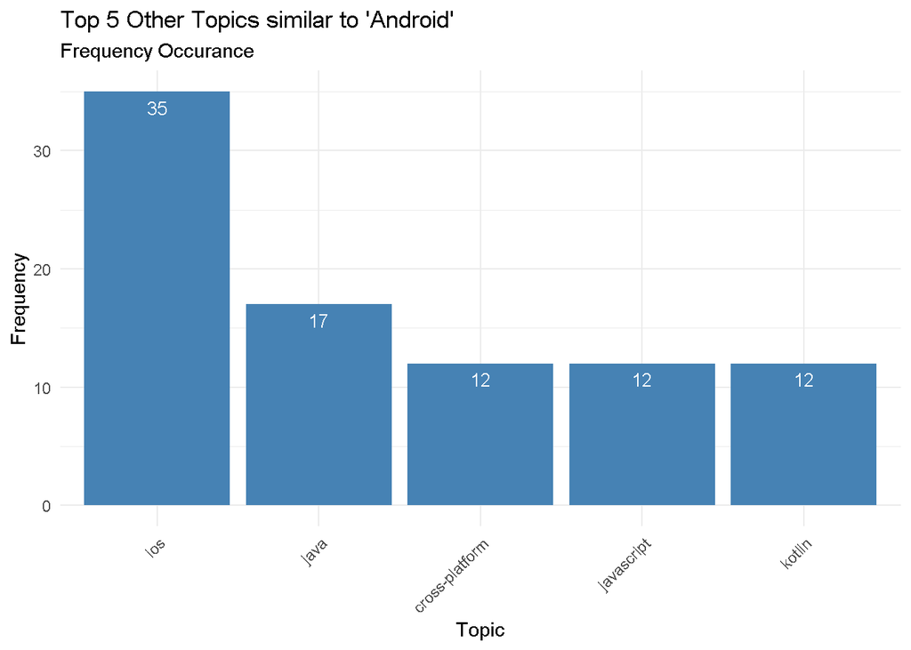

```r
item <- response$items
topics <- lapply(item, function(repo) repo$topics)

topics <- unlist(topics)
topics_freq <- table(topics)
sorted_topics_freq <- sort(topics_freq, decreasing = TRUE)

top_Topics_Occur <- names(sorted_topics_freq)[!grepl("^Android",names(sorted_topics_freq))][2:6]

data_Occur <- data.frame(
  topic = top_Topics_Occur,
  frequency = sorted_topics_freq[top_Topics_Occur]
)
data_Occur$frequency.Freq <- as.numeric(data_Occur$frequency.Freq)

ggplot(data_Occur, aes(x = reorder(topic, -frequency.Freq), y = frequency.Freq)) +
  geom_bar(stat = "identity", fill = "steelblue") +
  geom_text(aes(label=frequency.Freq), vjust=1.6, color="white", size=3.5)+
  labs(
    x = "Topic",
    y = "Frequency",
    title = "Top 5 Other Topics similar to 'Android'",
    subtitle = "Frequency Occurance",
  )  +
  theme_minimal() +
  theme(axis.text.x = element_text(angle = 45, hjust = 1))
```

## **Line Chart showing the trend of number of repos created each year**

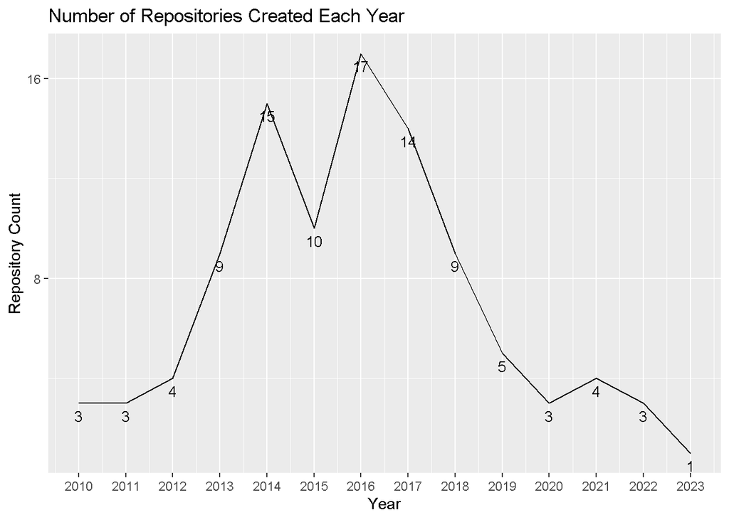

```r
years <- sapply(response$items, function(repo) as.integer(substr(repo$created_at, 1, 4)))
year_counts <- data.frame(year = unlist(years))
min_year <- min(year_counts$year)
max_year <- max(year_counts$year)
all_years <- data.frame(year = min_year:max_year)
year_counts <- year_counts %>%
  complete(year = all_years$year) %>%
   group_by(year) %>%
  summarise(count = n())
y_breaks <- seq(0, max(year_counts$count), by = 8)
ggplot(year_counts, aes(x = year, y = count)) +
  geom_line() +
  geom_text(aes(label=count), vjust=1.6, color="black", size=3.5)+
  labs(
    title = "Number of Repositories Created Each Year",
    x = "Year",
    y = "Repository Count"
  ) +
  scale_x_continuous(breaks = unique(year_counts$year)) +
  scale_y_continuous(breaks = y_breaks)
```

## **Above Line Chart Description**

- The above line shows the trend of the number of repos created each year
  - **Year with Highest created Repo** - In **2016** 17 repos are created
  - **Year with Lowest created Repo** - In **2023** only 1 repo is created
  - **Information about other years** - In **2014** 15 repos and in **2017** 14 repos are created